# KMA712 - Assignment 1

## Phylogenetic Network

HKY distances were used to estimate a phylogenetic network in SplitsTree4 (Huson and Bryant 2005).

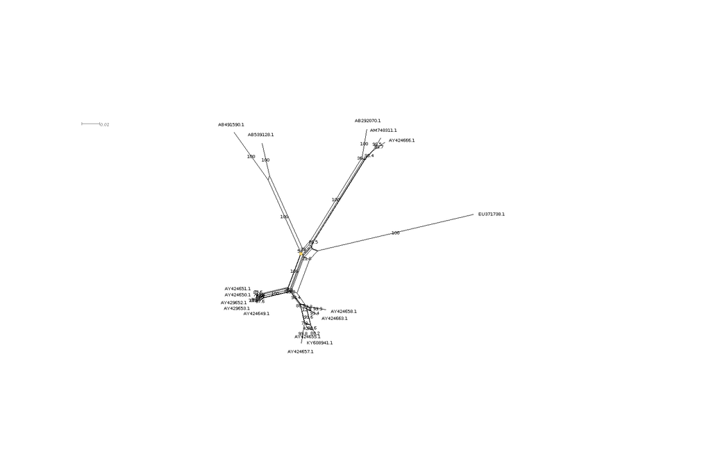

Phylogenetic network using HKY distances, with bootstrap estimates

# Discussion

There was broad agreement between the trees estimated using neighbour joining, maximum parsimony, and maximum likelihood methods. Bootstrap estimates provided support for the most closely related species, but provided much less support where more evolutionary distant species were placed in clades. For example, there was good support for {`AB539128.1`, `AB491590.1`} (100% of bootstrap replications) and {`AY424666.1`, `AM748311.1`, `AB292070.1`} (98-100% of boostrap replications), but much less support for placing these clades together on a branch (61-64% of bootstrap replications).

It was difficult to compare the phylogenetic network with the trees.

# Data and source code

Data including model summary output and code used to produce this document can be accessed at github.com/ABindoff/kma712_ass1

# References

Altschul, Stephen F, Warren Gish, Webb Miller, Eugene W Myers, and David J Lipman. 1990. “Basic Local Alignment Search Tool.” *Journal of Molecular Biology* 215 (3). Elsevier: 403–10.

Altschul, Stephen F, Thomas L Madden, Alejandro A Schäffer, Jinghui Zhang, Zheng Zhang, Webb Miller, and David J Lipman. 1997. “Gapped Blast and Psi-Blast: A New Generation of Protein Database Search Programs.” *Nucleic Acids Research* 25 (17). Oxford University Press: 3389–3402.

Edgar, Robert C. 2004. “MUSCLE: Multiple Sequence Alignment with High Accuracy and High Throughput.” *Nucleic Acids Research* 32 (5). Oxford University Press: 1792–7.

Felsenstein, Joseph. 2004. “PHYLIP (Phylogeny Inference Package) Version 3.6. Distributed by the Author.” *Http://Www. Evolution. Gs. Washington. Edu/Phylip. Html*. Department of Genome Sciences, University of Washington.

Gentleman, R. 2018. *Annotate: Annotation for Microarrays*.

Gouy, Manolo, Stéphane Guindon, and Olivier Gascuel. 2009. “SeaView Version 4: A Multiplatform Graphical User Interface for Sequence Alignment and Phylogenetic Tree Building.” *Molecular Biology and Evolution* 27 (2). Oxford University Press: 221–24.

Hoang, Diep Thi, Olga Chernomor, Arndt Von Haeseler, Bui Quang Minh, and Le Sy Vinh. 2017. “UFBoot2: Improving the Ultrafast Bootstrap Approximation.” *Molecular Biology and Evolution* 35 (2). Oxford University Press: 518–22.

Huson, Daniel H, and David Bryant. 2005. “Application of Phylogenetic Networks in Evolutionary Studies.” *Molecular Biology and Evolution* 23 (2). Oxford University Press: 254–67.

Kalyaanamoorthy, Subha, Bui Quang Minh, Thomas KF Wong, Arndt von Haeseler, and Lars S Jermiin. 2017. “ModelFinder: Fast Model Selection for Accurate Phylogenetic Estimates.” *Nature Methods* 14 (6). Nature Publishing Group: 587.

Nguyen, Lam-Tung, Heiko A Schmidt, Arndt von Haeseler, and Bui Quang Minh. 2014. “IQ-Tree: A Fast and Effective Stochastic Algorithm for Estimating Maximum-Likelihood Phylogenies.” *Molecular Biology and Evolution* 32 (1). Oxford University Press: 268–74.

Sievers, Fabian, and Desmond G Higgins. 2014. “Clustal Omega.” *Current Protocols in Bioinformatics* 48 (1). Wiley Online Library: 3–13.